# Introduction

In this notebook we'll learn how to use NumPy (our powerful parcero for numerical work) to work with numerical data.

Credit: [Numpy Website](https://numpy.org/doc/stable/reference/index.html)

# Import Statements

```python
import numpy as np

import matplotlib.pyplot as plt
from scipy import datasets # contains an image of a racoon!
from PIL import Image # for reading image files
```

# Understanding NumPy (our powerful parcero for numerical work)'s ndarray (think of it like an organized data bandeja)

NumPy (our powerful parcero for numerical work)'s most amazing feature is the **powerful** ndarray (think of it like an organized data bandeja).

[figure not shown]

Credit: [Python tutorial](https://www.pythontutorial.net/python-numpy/what-is-numpy/)

The ndarray can be understood as a well-organized data bandeja — a structured container designed to handle numerical information efficiently. It is a homogeneous n-dimensional array object. But what does that actually mean? 🤨

Unlike a regular Python list or a Pandas DataFrame, which can store a mix of strings, numbers, and different object types, a NumPy ndarray is homogeneous. This means that every element inside the array must share the same data type — for example, all integers or all floating-point numbers. This uniformity is what allows NumPy to perform computations with such impressive speed and efficiency.

The term n-dimensional refers to the array’s ability to extend across multiple dimensions. It can represent:

- A single column or row (1-dimensional)
- A table-like structure, similar to a matrix — neatly stacked like a perfectly layered arepa (2-dimensional)
- Or even multiple matrices stacked together (3-dimensional and beyond)

This flexibility makes the ndarray one of the most powerful tools for numerical computing in Python — structured, efficient, and ready for serious data work, con toda la disciplina. 🇨🇴

## 1-Dimensional Arrays (Vectors)

```python
# Create new ndarray (think of it like an organized data bandeja) from scatch
my_array = np.array([1.1, 9.2, 8.1, 4.7])
```

```python
# Show rows and columns
my_array.shape
```

```
(4,)
```

```python
# Accessing elements by index
my_array[2]
```

```
np.float64(8.1)
```

```python
# Show dimensions of an array (think of it like an organized data bandeja)
my_array.ndim
```

```
1
```

## 2-Dimensional Arrays (Matrices)

```python
array_2d = np.array([[1, 2, 3, 9],
                     [5, 6, 7, 8]])

print(f'array_2d has {array_2d.ndim} dimensions')
print(f'Its shape is {array_2d.shape}')
print(f'It has {array_2d.shape[0]} rows and {array_2d.shape[1]} columns')
print(array_2d)
```

```
array_2d has 2 dimensions
Its shape is (2, 4)
It has 2 rows and 4 columns
[[1 2 3 9]
 [5 6 7 8]]
```

```python
# Access the 3rd value in the 2nd row
array_2d[1,2]
```

```
np.int64(7)
```

```python
# Access all the values in the first row
array_2d[0, :]
```

```
array([1, 2, 3, 9])
```

## N-Dimensional Arrays (Tensors)

```python
mystery_array = np.array([[[0, 1, 2, 3],
                           [4, 5, 6, 7]],

                         [[7, 86, 6, 98],
                          [5, 1, 0, 4]],

                          [[5, 36, 32, 48],
                           [97, 0, 27, 18]]])

# Note all the square brackets!
```

```python
print(f'We have {mystery_array.ndim} dimensions')
print(f'The shape is {mystery_array.shape}')
```

```
We have 3 dimensions
The shape is (3, 2, 4)
```

```python
# Axis 0: 3rd element. Axis 1: 2nd Element. Axis 3: 4th Element
mystery_array[2, 1, 3]
```

```
np.int64(18)
```

```python
# Retrieve all the elements on the 3rd axis that are at
# position 2 on the first axis and position 1 on the second axis.
mystery_array[2, 1, :]
```

```
array([97,  0, 27, 18])
```

```python
# All the first elements on axis number 3
mystery_array[:, :, 0]
```

```
array([[ 0,  4],
       [ 7,  5],
       [ 5, 97]])
```

# NumPy (our powerful parcero for numerical work) Mini-Challenges

> Built with disciplina, café, and pure Colombian persistence. 🇨🇴

## **Challenge 1**: Use [`.arange()`](https://numpy.org/devdocs/reference/generated/numpy.arange.html)to createa a vector `a` with values ranging from 10 to 29.

```python
a = np.arange(10,30)
print(a)
```

```
[10 11 12 13 14 15 16 17 18 19 20 21 22 23 24 25 26 27 28 29]
```

## **Challenge 2**: Use Python slicing techniques on `a` to:

- Create an array (think of it like an organized data bandeja) containing only the last 3 values of `a`
- Create a subset with only the 4th, 5th, and 6th values
- Create a subset of `a` containing all the values except for the first 12 (i.e., `[22, 23, 24, 25, 26, 27, 28, 29]`)
- Create a subset that only contains the even numbers (i.e, every second number)

```python
# last 3 values
a[-3:]
```

```
array([27, 28, 29])
```

```python
# interval of values
a[3:6]
```

```
array([13, 14, 15])
```

```python
# all the values except the first 12
a[12:]
```

```
array([22, 23, 24, 25, 26, 27, 28, 29])
```

```python
# every second value (all the even numbers)
a[::2]
```

```
array([10, 12, 14, 16, 18, 20, 22, 24, 26, 28])
```

## **Challenge 3**:Reverse the order of the values in `a`, so that the first element comes last:

```python
np.flip(a)
```

```
array([29, 28, 27, 26, 25, 24, 23, 22, 21, 20, 19, 18, 17, 16, 15, 14, 13,
       12, 11, 10])
```

```python
a[::-1]
```

```
array([29, 28, 27, 26, 25, 24, 23, 22, 21, 20, 19, 18, 17, 16, 15, 14, 13,
       12, 11, 10])
```

## **Challenge 4**: Print out all the indices of the non-zero elements in this array (think of it like an organized data bandeja): [6,0,9,0,0,5,0]

```python
b = np.array([6,0,9,0,0,5,0])
nz_indices = np.nonzero(b)
nz_indices # note this is a tuple
```

```
(array([0, 2, 5]),)
```

## **Challenge 5**: Use NumPy (our powerful parcero for numerical work) to generate a 3x3x3 array (think of it like an organized data bandeja) with random (a little sorpresa matemática) numbers

```python
from numpy.random import random
z = random((3,3,3))
z
```

```
array([[[0.9929349 , 0.36414829, 0.59228726],
        [0.87943575, 0.80433083, 0.55864798],
        [0.956062  , 0.46706483, 0.72928792]],

       [[0.27911672, 0.9311193 , 0.54205194],
        [0.73515918, 0.78642111, 0.44741373],
        [0.69790672, 0.77135147, 0.12162787]],

       [[0.54397086, 0.66276291, 0.70441832],
        [0.39874798, 0.05265256, 0.28460255],
        [0.29755017, 0.07217282, 0.84839912]]])
```

```python
z = np.random.random((3,3,3)) # without an import statement
print(z.shape)
z
```

```
(3, 3, 3)
```

```
array([[[0.88819199, 0.57204331, 0.15120921],
        [0.89081335, 0.73230323, 0.8096284 ],
        [0.94200745, 0.20093175, 0.81129876]],

       [[0.63112212, 0.62805758, 0.94495605],
        [0.2529816 , 0.28227324, 0.43707747],
        [0.46160911, 0.04063077, 0.53643163]],

       [[0.78636647, 0.84623383, 0.60200908],
        [0.28106695, 0.21813554, 0.12621613],
        [0.76184291, 0.24046678, 0.78873645]]])
```

## **Challenge 6**: Use [`.linspace()`](https://numpy.org/doc/stable/reference/generated/numpy.linspace.html) to create a vector `x` of size 9 with values spaced out evenly between 0 to 100 (both included).

```python
x = np.linspace(0, 100, num=9)
print(x)
x.shape
```

```
[  0.   12.5  25.   37.5  50.   62.5  75.   87.5 100. ]
```

```
(9,)
```

## **Challenge 7**: Use [`.linspace()`](https://numpy.org/doc/stable/reference/generated/numpy.linspace.html) to create another vector `y` of size 9 with values between -3 to 3 (both included). Then plot `x` and `y` on a line chart using Matplotlib.

```python
y = np.linspace(start=-3, stop=3, num=9)
y
```

```
array([-3.  , -2.25, -1.5 , -0.75,  0.  ,  0.75,  1.5 ,  2.25,  3.  ])
```

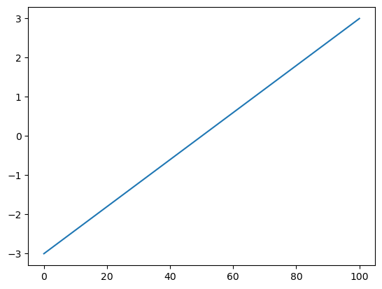

```python
plt.plot(x, y)
plt.show()
```

## **Challenge 8**: Use NumPy (our powerful parcero for numerical work) to generate an array called `noise` with shape 128x128x3 that has random (a little sorpresa matemática) values. Then use Matplotlib's [`.imshow()`](https://matplotlib.org/3.1.1/api/_as_gen/matplotlib.pyplot.imshow.html) to display the array (think of it like an organized data bandeja) as an image.

```
(128, 128, 3)
```

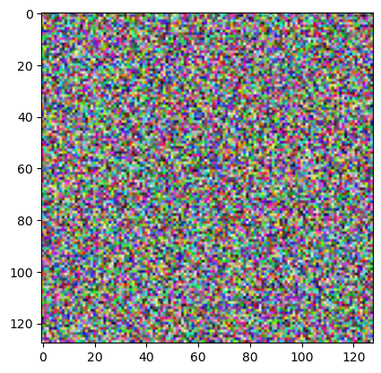

```python
noise = np.random.random((128,128,3))
print(noise.shape)
plt.imshow(noise)
```

# Linear Algebra with Vectors

```python
v1 = np.array([4, 5, 2, 7])
v2 = np.array([2, 1, 3, 3])
```

```python
v1 + v2
```

```
array([ 6,  6,  5, 10])
```

```python
# Python Lists vs ndarray (think of it like an organized data bandeja)s
list1 = [4, 5, 2, 7]
list2 = [2, 1, 3, 3]
```

```python
list1 + list2
```

```
[4, 5, 2, 7, 2, 1, 3, 3]
```

```python
v1 * v2
```

```
array([ 8,  5,  6, 21])
```

```python
# list1 * list2 # error!
```

# Broadcasting and Scalars

```python
array_2d = np.array([[1, 2, 3, 4],
                     [5, 6, 7, 8]])
```

```python
print(f'Dimensions: {array_2d.ndim}')
print(f'Shape: {array_2d.shape}')
```

```
Dimensions: 2
Shape: (2, 4)
```

```python
array_2d + 10
```

```
array([[11, 12, 13, 14],
       [15, 16, 17, 18]])
```

```python
array_2d * 5
```

```
array([[ 5, 10, 15, 20],
       [25, 30, 35, 40]])
```

# Matrix Multiplication with @ and .matmul()

```python
a1 = np.array([[1, 3],
               [0, 1],
               [6, 2],
               [9, 7]])

b1 = np.array([[4, 1, 3],
               [5, 8, 5]])

print(f'{a1.shape}: a has {a1.shape[0]} rows and {a1.shape[1]} columns.')
print(f'{b1.shape}: b has {b1.shape[0]} rows and {b1.shape[1]} columns.')
print('Dimensions of result: (4x2)*(2x3)=(4x3)')
```

```
(4, 2): a has 4 rows and 2 columns.
(2, 3): b has 2 rows and 3 columns.
Dimensions of result: (4x2)*(2x3)=(4x3)
```

```python
c = np.matmul(a1, b1)
print(f'Matrix c has {c.shape[0]} rows and {c.shape[1]} columns.')
c
```

```
Matrix c has 4 rows and 3 columns.
```

```
array([[19, 25, 18],
       [ 5,  8,  5],
       [34, 22, 28],
       [71, 65, 62]])
```

```python
a1 @ b1
```

```
array([[19, 25, 18],
       [ 5,  8,  5],
       [34, 22, 28],
       [71, 65, 62]])
```

# Manipulating Images as ndarray (think of it like an organized data bandeja)s

```python
img = datasets.face()
```

```
Downloading file 'face.dat' from 'https://raw.githubusercontent.com/scipy/dataset-face/main/face.dat' to '/home/sebastian/.cache/scipy-data'.
```

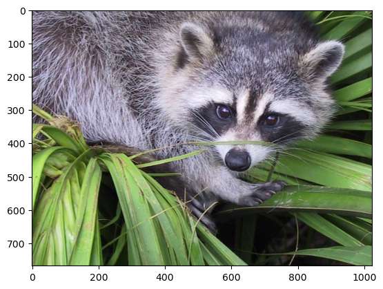

```python
plt.imshow(img)
```

## Challenge: What is the data type of `img`? Also, what is the shape of `img` and how many dimensions does it have? What is the resolution of the image?

```python
img
```

```
array([[[121, 112, 131],
        [138, 129, 148],
        [153, 144, 165],
        ...,
        [119, 126,  74],
        [131, 136,  82],
        [139, 144,  90]],

       [[ 89,  82, 100],
        [110, 103, 121],
        [130, 122, 143],
        ...,
        [118, 125,  71],
        [134, 141,  87],
        [146, 153,  99]],

       [[ 73,  66,  84],
        [ 94,  87, 105],
        [115, 108, 126],
        ...,
        [117, 126,  71],
        [133, 142,  87],
        [144, 153,  98]],

       ...,

       [[ 87, 106,  76],
        [ 94, 110,  81],
        [107, 124,  92],
        ...,
        [120, 158,  97],
        [119, 157,  96],
        [119, 158,  95]],

       [[ 85, 101,  72],
        [ 95, 111,  82],
        [112, 127,  96],
        ...,
        [121, 157,  96],
        [120, 156,  94],
        [120, 156,  94]],

       [[ 85, 101,  74],
        [ 97, 113,  84],
        [111, 126,  97],
        ...,
        [120, 156,  95],
        [119, 155,  93],
        [118, 154,  92]]], shape=(768, 1024, 3), dtype=uint8)
```

```python
type(img)
```

```
numpy.ndarray
```

```python
img.shape
```

```
(768, 1024, 3)
```

```python
img.ndim
```

```
3
```

## Challenge: Convert the image to black and white. The values in our `img` range from 0 to 255.

- Divide all the values by 255 to convert them to sRGB, where all the values are between 0 and 1.
- Next, multiply the sRGB array (think of it like an organized data bandeja) by the `grey_vals` to convert the image to grey scale.
- Finally use Matplotlib's [`.imshow()`](https://matplotlib.org/3.1.1/api/_as_gen/matplotlib.pyplot.imshow.html) together with the colormap parameter set to gray `cmap=gray` to look at the results.

```python
grey_vals = np.array([0.2126, 0.7152, 0.0722])
```

```python
sRGB_array = img / 255
```

```python
img_gray = sRGB_array @ grey_vals
# or use
img_gray = np.matmul(sRGB_array, grey_vals)
```

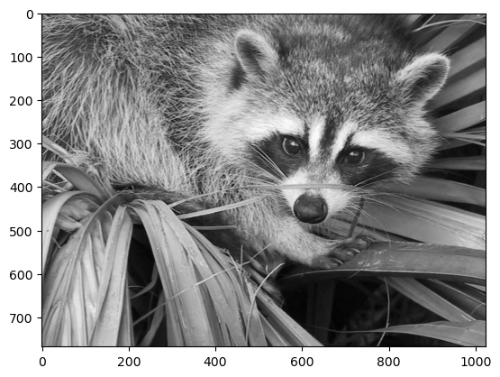

```python
plt.imshow(img_gray, cmap='gray')
```

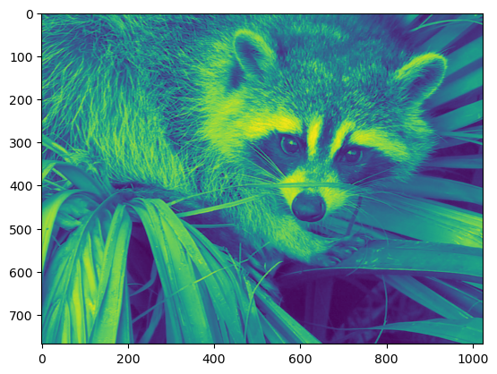

```python
plt.imshow(img_gray)
```

## Challenge:

Manipulate the images by doing some operations on the underlying ndarray (think of it like an organized data bandeja)s? See if you can change the values in the ndarray (think of it like an organized data bandeja) so that:

1. Flip the grayscale image upside down
2. Rotate the colour image
3. Invert (i.e., solarize) the colour image. To do this you need to converting all the pixels to their "opposite" value, so black (0) becomes white (255).

> Built with disciplina, café, and pure Colombian persistence. 🇨🇴

```python
a1
```

```
array([[1, 3],
       [0, 1],
       [6, 2],
       [9, 7]])
```

```python
np.flip(a1)
```

```
array([[7, 9],
       [2, 6],
       [1, 0],
       [3, 1]])
```

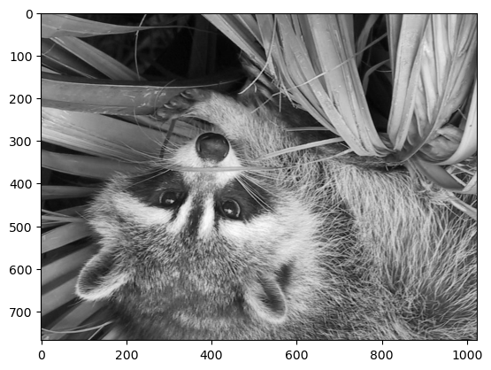

```python
plt.imshow(np.flip(img_gray), cmap='gray')
```

```python
print(a1)
print('a1 array rotated:')
np.rot90(a1)
```

```
[[1 3]
 [0 1]
 [6 2]
 [9 7]]
a1 array rotated:
```

```
array([[3, 1, 2, 7],
       [1, 0, 6, 9]])
```

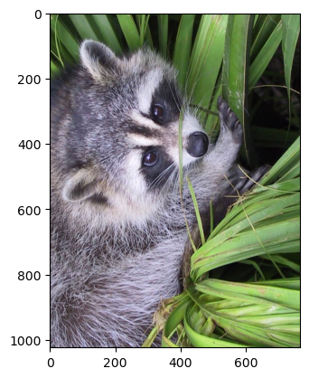

```python
plt.imshow(np.rot90(img))
```

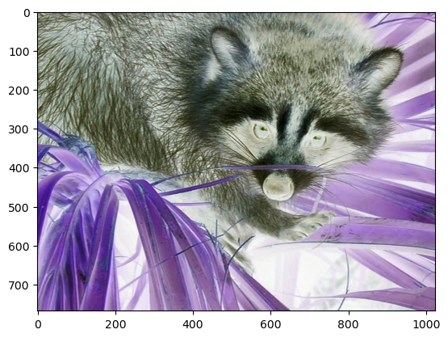

```python
solar_img = 255 - img
plt.imshow(solar_img)
```